# DEM 7283 - Count Data Models

Corey S. Sparks, PhD

28 February, 2022

# Macro demographic data analysis

Prior to the advent in the 1960’s of large scale social surveys like the General Social Survey (GSS), most demographic research was done not on individuals but on aggregates, because that’s how data were available. If you look at texts such as Keyfitz (1968), all of the examples are for national level calculations, and many nations did not have sufficient data availability to produce quality statistical summaries of their populations, resulting in publications such as the United Nations Population Division’s famous Manual X (1983), which gave pragmatic formulas to measure a wide variety of demographic indicators at the national level using basic inputs, usually available from census summaries.

Paul Voss (2007) describes most demography (and certainly most demographic studies prior to the 1970’s and 1980’s) as **Macro** demography. Voss also mentions that prior to the availability of individual level microdata, all demography was macro-demography, and most demographic studies were spatial in nature, because demographic data were only available in spatial units corresponding to administrative areas. Typical types of geographic areas would be counties, census tracts, ZIP codes, state or nations.

In the macro-demographic perspective on demography, observations are typically places, areas, or some other aggregate level of individuals. We do not observe the individual people themselves often times. An example of this is if you were to have access to an aggregate count of deaths in a region, even if the deaths were classified by age and sex, you still would be dealing with data that ignores, or has no index to the more nuanced characteristics of the individual decedents themselves. That being said, data such as these are invaluable, and most demographic summaries of individual-level data would aggregate based on the characteristics of the individuals any way. The macro scale principal is illustrated below, where all of the variables we observe are a scale above the individual person.

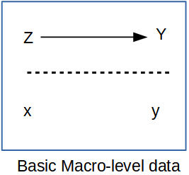

Macro Level Proposition

Such **macro-level propositions** are hypothesized relationships among variables ($\rightarrow$) measured at a macro scale ($Z$ and $Y$), which ignores individual level data, mostly because we don’t observe individuals ($x$ and $y$) in many of these kinds of analysis.

If all we looked at were the individuals within the population, we would be overwhelmed by the variation that we would see, and we wouldn’t be doing statistics anymore, we would be trying to process a million anecdotes, and the plural of anecdote is not data. By aggregating across basic demographic groups, such as age and sex, demographers begin to tease apart the differences that we are interested in. If we go a little further and, data willing, aggregate not only across these fundamental demographic groups, but also across some kind of place-based areal unit, then we adding an extremely important part of human existence: the **where** part of where we live.

This presents an attractive view of populations and typically data on places are more widely available, but there are caveats we must be aware of. If we are using purely aggregate data in our analysis, meaning that we do not have access to the individual level microdata, then our ability to observe variation within a place is extremely limited, if not impossible.

The goal of this chapter is to illustrate how places are a special unit of analysis, and the types of data we often see at the place level are very different from individual level surveys. Additionally, the analysis of place-based data is similar to survey data in that places are do not necessarily represent random observations, and so analyzing data on places often requires special modifications to statistical models. In this chapter, I show how the the linear regression model can be expanded in several ways and illustrate the generalized linear model as a very useful and extendable tool to analyze data on places and especially when we are analyzing rates as demographers often do.

## Getting data on places

In the macro-demographic perspective on demography, observations are typically places, areas, or some other aggregate level of individuals. We do not observe the individual people themselves often times. An example of this is if you were to have access to an aggregate count of deaths in a region, even if the deaths were classified by age and sex, you still would be dealing with data that ignores, or has no index to the more nuanced characteristics of the individual decedents themselves. That being said, data such as these are invaluable, and most demographic summaries of individual-level data would aggregate based on the characteristics of the individuals any way. The macro scale principal is illustrated below, where all of the variables we observe are a scale above the individual person.

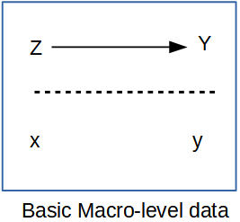

Macro Level Proposition

Such **macro-level propositions** are hypothesized relationships among variables ($\rightarrow$) measured at a macro scale ($Z$ and $Y$), which ignores individual level data, mostly because we don’t observe individuals ($x$ and $y$) in many of these kinds of analysis.

If all we looked at were the individuals within the population, we would be overwhelmed by the variation that we would see, and we wouldn’t be doing statistics anymore, we would be trying to process a million anecdotes, and the plural of anecdote is not data. By aggregating across basic demographic groups, such as age and sex, demographers begin to tease apart the differences that we are interested in. If we go a little further and, data willing, aggregate not only across these fundamental demographic groups, but also across some kind of place-based areal unit, then we adding an extremely important part of human existence: the **where** part of where we live.

This presents an attractive view of populations and typically data on places are more widely available, but there are caveats we must be aware of. If we are using purely aggregate data in our analysis, meaning that we do not have access to the individual level microdata, then our ability to observe variation within a place is extremely limited, if not impossible.

The goal of this chapter is to illustrate how places are a special unit of analysis, and the types of data we often see at the place level are very different from individual level surveys. Additionally, the analysis of place-based data is similar to survey data in that places are do not necessarily represent random observations, and so analyzing data on places often requires special modifications to statistical models. In this chapter, I show how the the linear regression model can be expanded in several ways and illustrate the generalized linear model as a very useful and extendable tool to analyze data on places and especially when we are analyzing rates as demographers often do.

## Getting data on places

Typically when thinking about data on places, we are really referring to some sort of administrative geography, such as nations, states, region, and census tracts. While these are often readily available (and I’ll show some R package that can easily get data from the web), we often have to use these as proxy measures of more interesting social spaces like neighborhoods and other types of activity spaces. These social spaces are harder to get data on, typically because they are more fluid in their definitions, and there is generally not a systematic effort to produce data on socially defined spaces on national scales. This is a big part of doing macro demography, defining the scale and the unit of analysis, both because we need to define the scope of our work, but also we are very much constrained by the availability of data for our projects. For instance, I may want to look at national scale inequality in mortality risk in neighborhoods in the United States, but you immediately face a couple of hurdles. No national data source identifies sub-city residential location for death certificates, also, what are neighborhoods? Again, they’re probably some socially defined space that may not be available from a national scale source. To get around this, we may have to settle for a state-level analysis, because state vital registration systems will often allow researchers to use more fine-scale geographic data on death certificates (such as latitude/longitude of the decedent’s residence), and once we have very fine scale geographic data on the vital events, we could potentially find data on some more socially defined spaces, perhaps from cities who often maintain geographic data on neighborhoods specific to that city. OK, so that’s fine, but then you still run into the “what’s my denominator” problem, where you have no baseline population data on the age and sex breakdown of the population, or even the population size of these places, because federal agencies don’t produce estimates for such small scale areas. *This is frustrating*. Often when advising students on their dissertation projects, I have to have this moment of truth where I lay out the problems of the mixing of geographic scales for their projects, and the hard reality of the lack of data on so many things they would like to study. Often what happens is that we have to proxy our ideal places with places for which we can find data. You see this a lot in the population health literature, where people want to analyze *neighborhoods* but all they have are census tracts. Tracts aren’t social spaces! They’re arbitrary areas of 3 to 5 thousand people, that change every 10 years, that the Census uses to count people. Likewise, counties are very rich areas to find data for, but they are not really activity spaces or neighborhoods, but they may be areas that have some policy making authority (such as county health departments) that *could* be relevant for something. States are also nice geographies, they’re very large, so you loose the ability to contextualize behavior on a fine spatial scale, but states make a lot of decisions that affect the lives of their residents, often more than national decisions. States have become very popular units of analysis in the health literature again, primarily as a result of differential adoption of portions of the Patient Protection and Affordable Care Act of 2010 (Soni, Hendryx, and Simon 2017; Courtemanche et al. 2019). This being said, many times when we do an analysis on places, that analysis has lots of limitations, which we must acknowledge, and analyses such as these are often called *ecological* analyses because we are examining associations at the macro scale, and we do not observe individual level outcomes.

## US contexts

The US Census bureau produces a wide variety of geographic data products that are the most widely used forms of geographic data for demographic studies in the United States. The TIGER Line Files data consist of geographic data with census bureau GEOIDs attached so they can be linked to any number of federal statistical products. They do not contain demographic data themselves, but are easily linked. The `tigris` package in R provides a direct way to download any TIGER line file data type directly in a R session as either a *simple feature* class or as a *Spatial_DataFrame* (Walker 2021).

Using the `tigris` package is very easy and its functions fit directly into the tidyverse as well. Below, I download two layers of information, first the state polygon for New York state, and the census tracts within the state and overlay the two datasets on each other. The package has a function for each type of geography that you would want, for example `states()` downloads state level geographies and `tracts()` does the same for census tracts. The functions have some common arguments, including `cb = TRUE/FALSE` so you can choose cartographic boundary files or not. Cartographic boundary files are lower resolution, smaller files that are often used for thematic mapping. Also `year =` will allow you to get different annual vintages of the data. The `tracts()` function also allows you to obtain geographies for specific counties within a state.

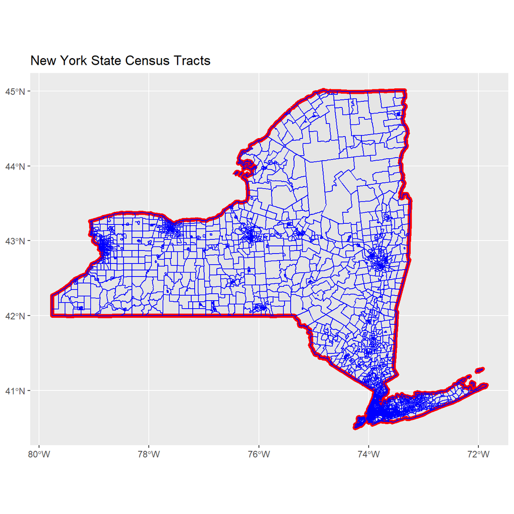

```r
library(tigris)

nyst <- states(cb = TRUE,
               year = 2010) %>%
  filter(NAME == "New York")

nyst_ct <- tracts(state = "NY",
                  cb = TRUE,
                  year = 2010)

ggplot(data=nyst)+
  geom_sf(color = "red",
          lwd = 2)+
   geom_sf(data = nyst_ct,
           fill = NA,
           color = "blue") +
  ggtitle(label = "New York State Census Tracts")
```

### Tidycensus

Another package the provides access to the US Census Bureau Decennial census summary file , the American Community Survey, Census population estimates, migration flow data and Census Public Use Microdata Sample (PUMS) data is `tidycensus` (Walker and Herman 2021). The `tidycensus` package primarily works to allow users to use the Census Bureau’s Application Programming Interface (API) to download Census summary file data for places within an R session. This removes the need to download separate files to your computer, and allows users to produce visualizations of Census data easily. The package is actively maintained and has several online tutorials on how to use it.[^1] Depending on which data source you are interested in, there are functions that allow extracts from them. The ACS data is accessed through the `get_acs()` function, likewise the decennial census data is accessed using the `get_decennial()` function. The package also allows users to test for differences in ACS estimates either across time or between areas using the `significance()` function.

The package requires users to obtain a developer API key from the Census Bureau’s developer page[^2] and install it on your local computer. The package has a function that helps you install the key to your `.Renviron` file. It is used like this:

```r
census_api_key(key = "yourkeyhere", install = TRUE)
```

which only needs to be done once.

```r
library(tidycensus)
```

```r
nyny <- get_acs(geography = "tract",
                year = 2018,
                state = "NY",
                county = "061",
                variables = "DP03_0119PE",
                output = "wide",
                geometry = TRUE)
```

The tabular output shows the Estimate column ending in *E* and the ACS margin of error column ending in *M*.

```r
knitr::kable(x = head(nyny),
             format = "html")
```

| GEOID | NAME | DP03_0119PE | DP03_0119PM | geometry |
| --- | --- | --- | --- | --- |
| 36061020101 | Census Tract 201.01, New York County, New York | 0.0 | 20.0 | MULTIPOLYGON (((-73.96155 4… |
| 36061020701 | Census Tract 207.01, New York County, New York | 24.1 | 17.0 | MULTIPOLYGON (((-73.95922 4… |
| 36061022200 | Census Tract 222, New York County, New York | 18.5 | 9.1 | MULTIPOLYGON (((-73.95068 4… |
| 36061022600 | Census Tract 226, New York County, New York | 15.5 | 9.4 | MULTIPOLYGON (((-73.94703 4… |
| 36061000600 | Census Tract 6, New York County, New York | 37.5 | 9.8 | MULTIPOLYGON (((-73.99256 4… |
| 36061001600 | Census Tract 16, New York County, New York | 22.2 | 8.5 | MULTIPOLYGON (((-73.99606 4… |

The `geometry = TRUE` option also download the TIGER line file for the requested geography and merges it to the ACS estimates. This allows you to immediately map the estimates for the requested geographies.

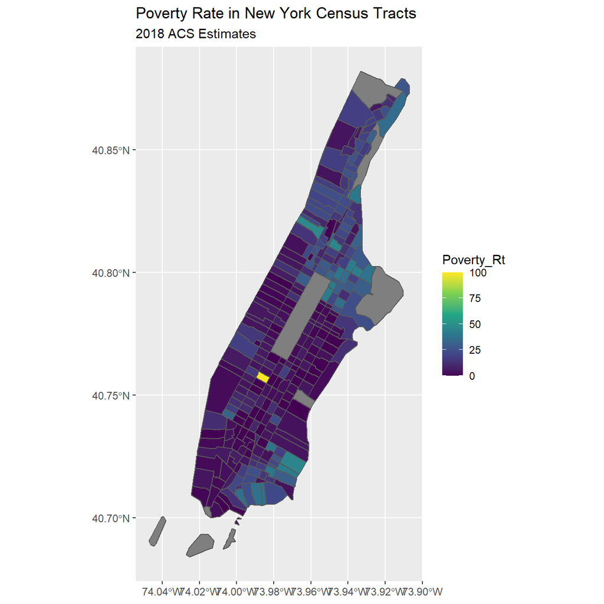

```r
# Create map of estimates
nyny %>%
  rename (Poverty_Rt = DP03_0119PE)%>%
  ggplot(aes(fill = Poverty_Rt))+
  geom_sf()+
  scale_fill_viridis_c()+
  ggtitle ( label = "Poverty Rate in New York Census Tracts",
            subtitle = "2018 ACS Estimates")
```

One common task that we should do when visualizing ACS estimates is to examine the coefficient of variation in the estimates. This gives us an idea of how stable the estimates are. This can be particularly problematic as we use smaller and smaller geographies in our analysis. Below, I calculate the coefficient of variation for the estimates and map it. To get the standard error of the ACS estimate, I divide the margin of error by 1.645, following Census Bureau recommendations (Bureau 2019).

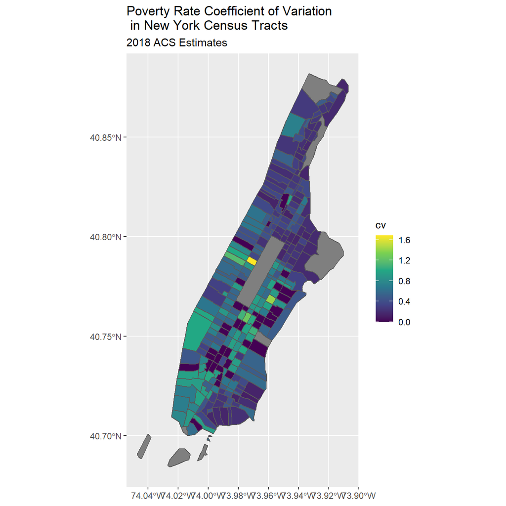

```r
nyny %>%
  mutate ( cv =ifelse(test = DP03_0119PE==0,
                      yes = 0,
                      no = (DP03_0119PM/1.645) / DP03_0119PE))%>%
  ggplot(aes(fill = cv))+
  geom_sf()+
  scale_fill_viridis_c()+
  ggtitle ( label = "Poverty Rate Coefficient of Variation\n in New York Census Tracts",
            subtitle = "2018 ACS Estimates")
```

which shows areas with the highest coefficient of variations mostly adjacent to Central Park and on the lower west side of Manhattan. These are also the areas with the lowest poverty rates in the city, so the estimates have low precision because so few respondents report incomes below the poverty line.

### IPUMS NHGIS

The IPUMS NHGIS project[^3] is also a great source for demographic data on US places, and allows you to select many demographic tables for census data products going back to the 1790 census (Manson et al. 2021). When you perform an extract from the site, you can get both data tables and ESRI shapefiles for your requested geographies. The IPUMS staff have created several tutorials which go through how to construct a query from their site.[^4] Below, I use the `sf` library to read in the geographic data from IPUMS and the tabular data and join them.

```r
library(sf)
ipums_co <- read_sf("C:/Users/ozd504/OneDrive - University of Texas at San Antonio/projects/book_data/US_county10_2000.shp")


im_dat <- readr::read_csv("C:/Users/ozd504/Documents/Github/dem-stats-book/data/nhgis0025_ds231_2005_county.csv")
```

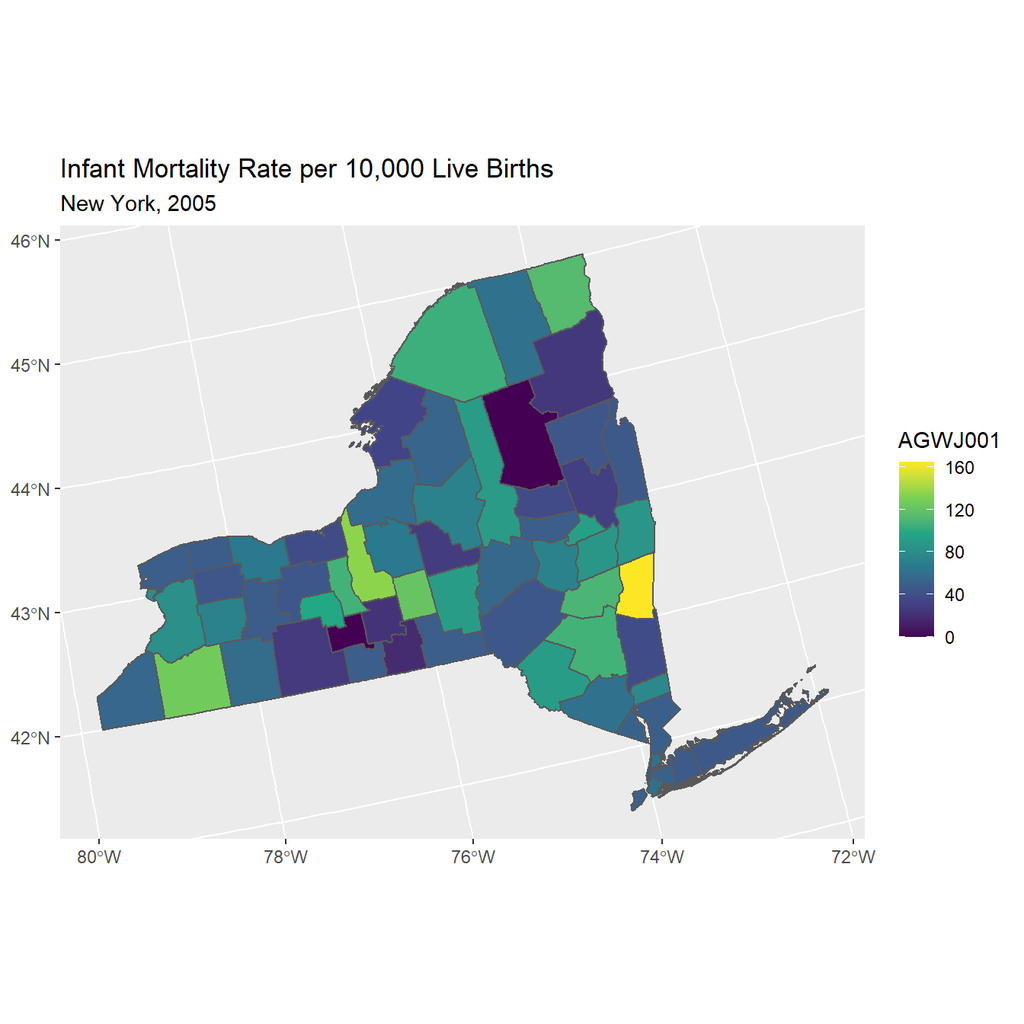

```r
m_dat <- left_join(x = ipums_co,
                   y = im_dat,
                   by = c("GISJOIN" = "GISJOIN"))

m_dat %>%
  filter(STATE == "New York" )%>%
  ggplot()+
  geom_sf(aes (fill = AGWJ001))+
  scale_fill_viridis_c()+
  ggtitle(label = "Infant Mortality Rate per 10,000 Live Births",
          subtitle = "New York, 2005")
```

## Statistical models for place-based data

Data on places is often analysed in the same ways as data on individuals, with some notable complications. The remainder of this chapter introduces the regression framework for analyzing data at the macro level, first by a review of the linear model and its associated pitfalls, and then the generalized linear model with a specific focus on the analysis of demographic count outcomes that are commonly observed for places.

In the example below, I use data from the U.S. Health Resources and Services Administration Area Health Resource File (AHRF), which is a produced annually and includes a wealth of information on current and historical data on health infrastructure in U.S. counties, as well as data from the Census Bureau, and the National Center for Health Statistics. The AHRF is publicly available, and we can read the data directly from the HHS website as a SAS format `.sas7bdat` data set within a ZIP archive. R can read this file to your local computer then extract it using the commands below. I would strongly encourage you consulting the AHRF codebook available from the HRSA website[^5].

```r
#create temporary file on  your computer
temp <- tempfile()

#Download the SAS dataset as a ZIP compressed archive
download.file("https://data.hrsa.gov/DataDownload/AHRF/AHRF_2019-2020_SAS.zip", temp)

#Read SAS data into R
ahrf<-haven::read_sas(unz(temp,
                          filename = "ahrf2020.sas7bdat"))

rm(temp)
```

Next, I remove many of the variables in the AHRF and recode several others. In the analysis examples that follow in this chapter, I will focus on the outcome of low birth weight births, measured at the county level.

```r
library(tidyverse)

ahrf2<-ahrf%>%
  mutate(cofips = f00004,
         coname = f00010,
         state = f00011,
         popn =  f1198416,
         births1618 =  f1254616,
         lowbw1618 = f1255316,
         fampov14 =  f1443214,
         lbrate1618 = 1000*(f1255316/f1254616),  #Rate per 1000 births
         rucc = as.factor(f0002013),
         hpsa16 = case_when(.$f0978716 == 0 ~ 'no shortage',
                            .$f0978716 == 1 ~ 'whole county shortage',
                            .$f0978716 == 2 ~ 'partial county shortage'),
         obgyn15_pc= 1000*( f1168415 / f1198416 ) )%>%
  mutate(rucc = droplevels(rucc, ""))%>%
  dplyr::select(births1618,
                lowbw1618,
                lbrate1618,
                state,
                cofips,
                coname,
                popn,
                fampov14,
                rucc,
                hpsa16,
                obgyn15_pc)%>%
  filter(complete.cases(.))%>%
  as.data.frame()
```

In order to make a nice looking map of the outcome, I use the `tigris` package to fetch geographic data for US states and counties, then merge the county data to the AHRF data using `left_join()`

```r
options(tigris_class="sf")
library(tigris)
library(sf)
usco<-counties(cb = T, year= 2016)

usco$cofips<-usco$GEOID

sts<-states(cb = T, year = 2016)

sts<-st_boundary(sts)%>%
  filter(!STATEFP %in% c("02", "15", "60", "66", "69", "72", "78"))%>%
  st_transform(crs = 2163)

ahrf_m<-left_join(usco, ahrf2,
                    by = "cofips")%>%
  filter(is.na(lbrate1618)==F,
         !STATEFP %in% c("02", "15", "60", "66", "69", "72", "78"))%>%
  st_transform(crs = 2163)

glimpse(ahrf_m)
```

Here is a `ggplot()` histogram of the low birth weight rate for US counties.

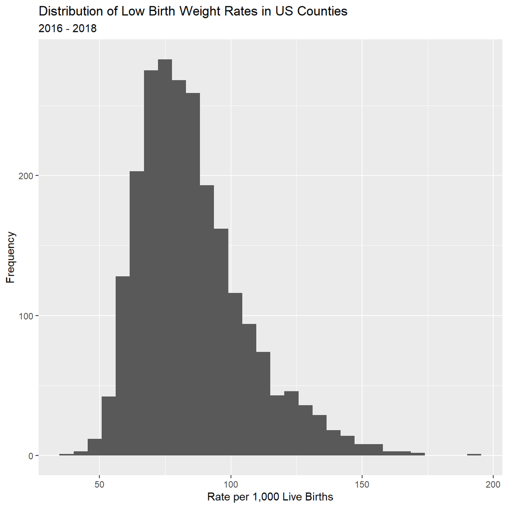

```r
ahrf_m%>%
  ggplot()+
  geom_histogram(aes(x = lbrate1618))+
  labs(title = "Distribution of Low Birth Weight Rates in US Counties",
       subtitle = "2016 - 2018")+
       xlab("Rate per 1,000 Live Births")+
  ylab ("Frequency")
```

Here, we do a basic map of the outcome variable for the continental US, and see the highest rates of low birth weight births in the US occur in the southeastern areas of the country. Notice, I do not color the boundaries of the counties in order to maximize the reader’s ability to see the variation, instead I show lines between states by overlaying the `sts` layer from above. I also add cartographic options of a scale bar and a north arrow, which I personally believe should be on any map shown to the public.

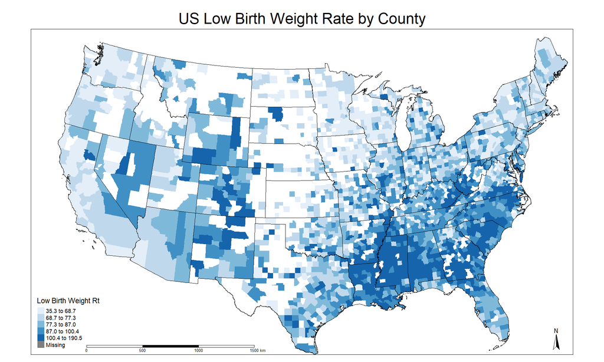

```r
library(tmap)

tm_shape(ahrf_m)+
  tm_polygons(col = "lbrate1618",
              border.col = NULL,
              title="Low Birth Weight Rt",
              palette="Blues",
              style="quantile",
              n=5,
              showNA=T, colorNA = "grey50")+
   tm_format(format= "World",
             main.title="US Low Birth Weight Rate by County",
            legend.position =  c("left", "bottom"),
            main.title.position =c("center"))+
  tm_scale_bar(position = c(.1,0))+
  tm_compass()+
tm_shape(sts)+
  tm_lines( col = "black")
```

When doing analysis of place-based data, maps are almost a fundamental aspect of the analysis and often convey much more information about the distribution of the outcome than either distribution plots or summary statistics.

## Basics of Generalized Linear Models

Up until now, we have been relying on linear statistical models which assumed the Normal distribution for our outcomes. A broader class of regression models, are *Generalized Linear Models* (Nelder and Wedderburn 1972; McCullagh and Nelder 1998), or **GLM**s, which allow for the estimation of a linear regression specification for outcomes that are not assumed to come from a Normal distribution. GLMs are a class of statistical models with three underlying components: A probability density appropriate to the outcome, a link function and a linear predictor. The *link function* is some mathematical function that links the mean of the specified probability distribution to the linear predictor of regression parameters and covariates. For example, the Normal distribution used by the OLS model has the mean, $\mu$, which is typically estimated using the *linear mean function* :
$$\mu = \beta_0 + \beta_1 x_1$$
Which describes the line that estimates the mean of the outcome variable as a linear function of $\beta$ parameters and the predictor variable $x_1$. The OLS, or *Gaussian* GLM model uses an *identity link* meaning there is no transformation of the linear mean function as it is connected to the mean of the outcome. This can be written as:

$$g(u) = g(E(Y)) = \beta_0 + \beta_1 x_1$$

```r
library(gtsummary)
glm1<- glm(lbrate1618 ~  fampov14 + rucc + hpsa16,
          data = ahrf_m,
          family =gaussian)


glm1%>%
  tbl_regression()
```

| **Characteristic** | **Beta** | **95% CI**<sup>1</sup> | **p-value** |
| --- | --- | --- | --- |
| % Families Below Poverty Level 2014-18 | 2.3 | 2.1, 2.4 | <0.001 |
| rucc |  |  |  |
| 01 | — | — |  |
| 02 | -1.9 | -4.3, 0.44 | 0.11 |
| 03 | -3.4 | -5.8, -0.94 | 0.007 |
| 04 | -6.7 | -9.4, -3.9 | <0.001 |
| 05 | -6.0 | -9.8, -2.2 | 0.002 |
| 06 | -3.9 | -6.2, -1.7 | <0.001 |
| 07 | -4.0 | -6.5, -1.5 | 0.002 |
| 08 | 0.45 | -3.7, 4.6 | 0.8 |
| 09 | -3.9 | -8.4, 0.61 | 0.090 |
| hpsa16 |  |  |  |
| no shortage | — | — |  |
| partial county shortage | -0.66 | -2.6, 1.3 | 0.5 |
| whole county shortage | 2.4 | -0.09, 4.8 | 0.060 |

<sup>*1*</sup> CI = Confidence Interval

```r
summary(glm1)
```

```
##
## Call:
## glm(formula = lbrate1618 ~ fampov14 + rucc + hpsa16, family = gaussian,
##     data = ahrf_m)
##
## Deviance Residuals:
##     Min       1Q   Median       3Q      Max
## -90.114  -10.345   -1.229    9.287   77.778
##
## Coefficients:
##                               Estimate Std. Error t value Pr(>|t|)
## (Intercept)                   62.26920    1.18901  52.371  < 2e-16 ***
## fampov14                       2.25805    0.06846  32.981  < 2e-16 ***
## rucc02                        -1.91854    1.20082  -1.598 0.110249
## rucc03                        -3.38658    1.25055  -2.708 0.006818 **
## rucc04                        -6.65483    1.40639  -4.732 2.36e-06 ***
## rucc05                        -5.96283    1.93739  -3.078 0.002110 **
## rucc06                        -3.94180    1.14317  -3.448 0.000575 ***
## rucc07                        -4.00730    1.28166  -3.127 0.001790 **
## rucc08                         0.45112    2.11062   0.214 0.830770
## rucc09                        -3.88365    2.29118  -1.695 0.090202 .
## hpsa16partial county shortage -0.66219    1.00767  -0.657 0.511148
## hpsa16whole county shortage    2.36214    1.25335   1.885 0.059601 .
## ---
## Signif. codes:  0 '***' 0.001 '**' 0.01 '*' 0.05 '.' 0.1 ' ' 1
##
## (Dispersion parameter for gaussian family taken to be 267.6184)
##
##     Null deviance: 981607  on 2323  degrees of freedom
## Residual deviance: 618734  on 2312  degrees of freedom
## AIC: 19599
##
## Number of Fisher Scoring iterations: 2
```

This output shows the same coefficients, and hypothesis test results compared to `summary(lm1)`, but the residual variances are reported differently. The GLM summary reports the Null and Residual deviance instead of the Residual standard errors reported by `summary(lm1)`. If we take the residual deviance and divide it by the residual degrees of freedom, and take the square root, we get the residual standard error reported by `summary(lm1)`:

```r
sqrt(glm1$deviance/glm1$df.residual)
```

```
## [1] 16.35905
```

The deviance in the GLM model is calculated in the same way as the residual sums of squares:

```r
glm1$deviance
```

```
## [1] 618733.7
```

We do not need to assume the identity function is the only one for the Gaussian GLM, for instance, the logarithmic link function can change the model to:

$$ln(Y) = \beta_0 + \beta_1 x_1 \\
Y = exp(\beta_0 + \beta_1 x_1) \\
Y = exp(\beta_0) * exp(\beta_1 x_1)$$
Which changes the model to no longer be additive in terms of the parameters for the logarithmic link function.

```r
glm2<- glm(lbrate1618 ~  fampov14 + rucc + hpsa16,
          data = ahrf_m,
          family =gaussian(link = "log"))
AIC(glm1, glm2)
```

|  | df | AIC |
| --- | --- | --- |
| glm1 | 13 | 19599.34 |
| glm2 | 13 | 19687.44 |

In this case, the identity link function is preferred because of the lower AIC.

**Different distributions have different link functions….**

The identity link function is appropriate for the Normal distribution, because this distribution can take any value from $- \infty$ to $\infty$, and so the linear mean function can also take those values, theoretically. Other distributions may not have this wide of a numeric range, so appropriate link functions have to be used to transform the linear mean function to the scale of the mean of a particular distribution. The most common distributions for the generalized linear model and their common link functions are shown below, along with common expressions for the mean and variance of their respective distributions.

| Distribution | Mean | Variance | Link Function | Range of Outcome |
| --- | --- | --- | --- | --- |
| Gaussian | $\mu$ | $\sigma^2$ | Identity | $(-\infty , \infty)$ |
| Binomial | $\pi$ | $n\pi(1-\pi)$ | $log \left (\frac{\pi}{1-\pi} \right )$ | $\frac{0,1,2,...n}{n}$ |
| Poisson | $\lambda$ | $\lambda$ | $log (\lambda)$ | $(0,1,2,...)$ |
| Gamma | $\mu$ | $\phi \mu^2$ | $log (\mu)$ | $(0, \infty)$ |
| Negative Binomial | $n(1-p)/p$ | $n(1-p)/p^2$ | $log (\mu)$ | $(0,1,2,...)$ |
| Student-t | $\mu$ | $\frac{\sigma^2 \nu}{\nu-2}$ | Identity | $-\infty , \infty$ |

While these are not all possible distributions for the GLM, these are distributions that are both widely used and commonly present not only in R but in other software as well. The `VGAM` package adds a much wider selection of both univariate and bivariate distributions for discrete and continuous outcomes.

### Binomial Distribution

You have probably seen the binomial distribution in either a basic statistics course, remember the coin flips? Or in the context of a logistic regression model. There are two ways the binomial distribution is typically used, the first is the context of logistic regression, where a special case of the binomial is used, called the *Bernoulli* distribution. This is the case of the binomial when there is basically a single coin flip, and you’re trying to estimate the probability that it is heads (or tails). This is said to be a single *trial*, and the outcome is either 1 or 0 (heads or tails). We will spend time in chapter 5 discussing the logistic regression model in the context of individual level data.

The second way the binomial is used is when you have multiple trials, and you’re trying to estimate the probability of the event occurring over these trials. In this case, your number of trials, $n$ can be large, and your number of successes, $y$ is the random variable under consideration. This usage of the binomial has a wide applicability for place-based demographic analysis, as the basic distribution for a demographic rate. I will commonly refer to this as the *count-based binomial distribution*.

The mean of the binomial distribution is a proportion or a probability, $\pi$, which tells you the probability of the event of interest occurs. Any model using the binomial distributor will be geared towards estimating this probability. The good thing is that, when we have count data, not just 1’s and 0’s, the same thing happens. The ratio or successes ($y$) to trials ($n$) is used to estimate $\pi$ and we build a model for that mean rate:

$$\text{Binomial} \binom{n}{y} = \frac{y}{n} = \pi = \text{some function of predictors}$$

The ratio $\frac{y}{n}$ is a rate or probability, and as such has very strict bounds. Probabilities cannot be less than 0 or greater than 1, so again, we should not use the Normal distribution here, since it is valid for all real numbers. Instead, we are using the binomial, but we still run into the problem of having a strictly bounded value, $\pi$ that we are trying to estimate with a linear function.

Enter the link function again.

The binomial distribution typically uses either a [logit](https://en.wikipedia.org/wiki/Logit) or [probit](https://en.wikipedia.org/wiki/Probit) link function, but others such as the [complementary log-log link function](http://data.princeton.edu/wws509/notes/c3s7.html) are also used in certain circumstances. For now we will use the *logit* function.

The logit transforms the probability, $\pi$, which is bound on the interval $[0,1]$ into a new unbounded interval similar to the normal distribution of $[-\infty, \infty]$. The transformation is knows a the *log-odd*s transformation, or *logit* for short. The odds of an event happening are the probability that something happens, divided by the probability it does not happen, in this case:

$$\text{odds}({\pi}) = \frac{\pi}{(1-\pi)}$$

Which is bound on the interval $[0, \infty]$, when we take the natural log of the odds, the value is transformed into the linear space, of $[-\infty, \infty]$.

$$\text{log-odds }({\pi}) = log \left ( \frac{\pi}{(1-\pi)} \right)$$

This can be modeled using a linear function of covariates now, without worrying about the original boundary problem:

$$log \left ( \frac{\pi}{1-\pi} \right) = \beta_0 +\beta_1 x_1$$

or more compactly:

$$logit (\pi) = \beta_0 +\beta_1 x_1$$

#### Binomial regression

The `glm()` function can estimate the count binomial model using the syntax `cbind( y, n-y)` in the outcome portion of the model formula.

```r
glmb<- glm(cbind(lowbw1618, births1618-lowbw1618) ~  fampov14 + rucc + hpsa16,
          data = ahrf_m,
          family = binomial)

glmb%>%
  tbl_regression()
```

| **Characteristic** | **log(OR)**<sup>1</sup> | **95% CI**<sup>1</sup> | **p-value** |
| --- | --- | --- | --- |
| % Families Below Poverty Level 2014-18 | 0.02 | 0.02, 0.02 | <0.001 |
| rucc |  |  |  |
| 01 | — | — |  |
| 02 | -0.01 | -0.02, -0.01 | 0.003 |
| 03 | -0.02 | -0.04, -0.01 | <0.001 |
| 04 | -0.06 | -0.08, -0.04 | <0.001 |
| 05 | -0.04 | -0.07, -0.01 | 0.004 |
| 06 | -0.02 | -0.04, -0.01 | 0.014 |
| 07 | -0.03 | -0.06, -0.01 | 0.016 |
| 08 | 0.04 | -0.02, 0.10 | 0.2 |
| 09 | -0.03 | -0.10, 0.03 | 0.3 |
| hpsa16 |  |  |  |
| no shortage | — | — |  |
| partial county shortage | -0.02 | -0.03, 0.00 | 0.011 |
| whole county shortage | 0.00 | -0.02, 0.03 | 0.8 |

<sup>*1*</sup> OR = Odds Ratio, CI = Confidence Interval

The output above shows the results of the model. The coefficients are on the log-odds scale, and typically would be converted to an odds-ratio by exponentiating them.

```r
glmb%>%
  tbl_regression(exponentiate=TRUE)
```

| **Characteristic** | **OR**<sup>1</sup> | **95% CI**<sup>1</sup> | **p-value** |
| --- | --- | --- | --- |
| % Families Below Poverty Level 2014-18 | 1.02 | 1.02, 1.02 | <0.001 |
| rucc |  |  |  |
| 01 | — | — |  |
| 02 | 0.99 | 0.98, 0.99 | 0.003 |
| 03 | 0.98 | 0.96, 0.99 | <0.001 |
| 04 | 0.95 | 0.93, 0.96 | <0.001 |
| 05 | 0.96 | 0.93, 0.99 | 0.004 |
| 06 | 0.98 | 0.96, 0.99 | 0.014 |
| 07 | 0.97 | 0.94, 0.99 | 0.016 |
| 08 | 1.05 | 0.98, 1.11 | 0.2 |
| 09 | 0.97 | 0.90, 1.03 | 0.3 |
| hpsa16 |  |  |  |
| no shortage | — | — |  |
| partial county shortage | 0.98 | 0.97, 1.00 | 0.011 |
| whole county shortage | 1.00 | 0.98, 1.03 | 0.8 |

<sup>*1*</sup> OR = Odds Ratio, CI = Confidence Interval

In this case, the odds ratio interpretation is not as clear as in the case of the Bernoulli case, in the context of individuals. When I interpret the coefficients for the count binomial, I describe them as *percent changes in the mean*. For example, the `fampov14` odds ratio is 1.02, I describe this result as: The low birth weight rate increases by 2 percent for every 1 percentage point increase in the poverty rate. We can see this by using the fitted values from `emmeans`, here I generate two cases where `fampov14` is exactly 1 percentage point different, and you can see the difference in the estimated rates.

```r
library(emmeans)
rg <- ref_grid(glmb,
               at=list( fampov14 = c(5, 6) ) )
emmeans(rg,
        specs = "fampov14",
        type = "response")
```

```
##  fampov14   prob       SE  df asymp.LCL asymp.UCL
##         5 0.0735 0.000474 Inf    0.0726    0.0745
##         6 0.0750 0.000470 Inf    0.0741    0.0760
##
## Results are averaged over the levels of: rucc, hpsa16
## Confidence level used: 0.95
## Intervals are back-transformed from the logit scale
```

We can calculate the percentage change in these two estimates:

```r
(.0750 - .0735)/.0750
```

```
## [1] 0.02
```

and confirm that it is 2 percent.

#### Application of the binomial to age standardization

The Binomial is very useful for conducting standardization of rates between groups to measure the differences. To show an example of how to do age standardization, I use data from the [CDC Wonder Compressed Mortality file](https://wonder.cdc.gov/mortSQL.html). The data are for the states of Texas and California for the year 2016, and are the numbers of deaths and population at risk in 13 age groups.

```r
library(gt)
txca <- readr::read_delim(url("https://raw.githubusercontent.com/coreysparks/dem-stats-book/master/data/CMF_TX_CA_age.txt?token=GHSAT0AAAAAABQZ5VMKFA7HBM5RY4QA3ORCYRGDHDA"),
                          delim = "\t",
                          quote = "\"",
                          skip=1,
                          col_names = c("State",
                                        "State_Code",
                                        "Age_Group",
                                        "Age_Group_Code",
                                        "Deaths",
                                        "Population",
                                        "Crude.Rate")
                          )%>%
  filter(Age_Group != "Not Stated")%>%
  mutate(Population = as.numeric(Population), Deaths = as.numeric(Deaths))
txca%>%
  gt()
```

| State | State_Code | Age_Group | Age_Group_Code | Deaths | Population | Crude.Rate |
| --- | --- | --- | --- | --- | --- | --- |
| California | 06 | < 1 year | 1 | 2057 | 498832 | 412.4 |
| California | 06 | 1-4 years | 1-4 | 397 | 1988540 | 20.0 |
| California | 06 | 5-9 years | 5-9 | 253 | 2539626 | 10.0 |
| California | 06 | 10-14 years | 10-14 | 277 | 2522475 | 11.0 |
| California | 06 | 15-19 years | 15-19 | 1076 | 2579986 | 41.7 |
| California | 06 | 20-24 years | 20-24 | 2090 | 2812191 | 74.3 |
| California | 06 | 25-34 years | 25-34 | 5201 | 5917785 | 87.9 |
| California | 06 | 35-44 years | 35-44 | 7032 | 5159932 | 136.3 |
| California | 06 | 45-54 years | 45-54 | 16370 | 5195297 | 315.1 |
| California | 06 | 55-64 years | 55-64 | 34176 | 4688718 | 728.9 |
| California | 06 | 65-74 years | 65-74 | 45834 | 3089002 | 1483.8 |
| California | 06 | 75-84 years | 75-84 | 59121 | 1535300 | 3850.8 |
| California | 06 | 85+ years | 85+ | 88331 | 722333 | 12228.6 |
| Texas | 48 | < 1 year | 1 | 2287 | 405899 | 563.4 |
| Texas | 48 | 1-4 years | 1-4 | 433 | 1613272 | 26.8 |
| Texas | 48 | 5-9 years | 5-9 | 276 | 2038319 | 13.5 |
| Texas | 48 | 10-14 years | 10-14 | 319 | 2029062 | 15.7 |
| Texas | 48 | 15-19 years | 15-19 | 999 | 1970588 | 50.7 |
| Texas | 48 | 20-24 years | 20-24 | 1829 | 2005169 | 91.2 |
| Texas | 48 | 25-34 years | 25-34 | 4405 | 4085728 | 107.8 |
| Texas | 48 | 35-44 years | 35-44 | 6292 | 3726287 | 168.9 |
| Texas | 48 | 45-54 years | 45-54 | 13636 | 3519013 | 387.5 |
| Texas | 48 | 55-64 years | 55-64 | 28663 | 3116019 | 919.9 |
| Texas | 48 | 65-74 years | 65-74 | 37506 | 2008449 | 1867.4 |
| Texas | 48 | 75-84 years | 75-84 | 44144 | 957001 | 4612.7 |
| Texas | 48 | 85+ years | 85+ | 51173 | 387790 | 13196.1 |

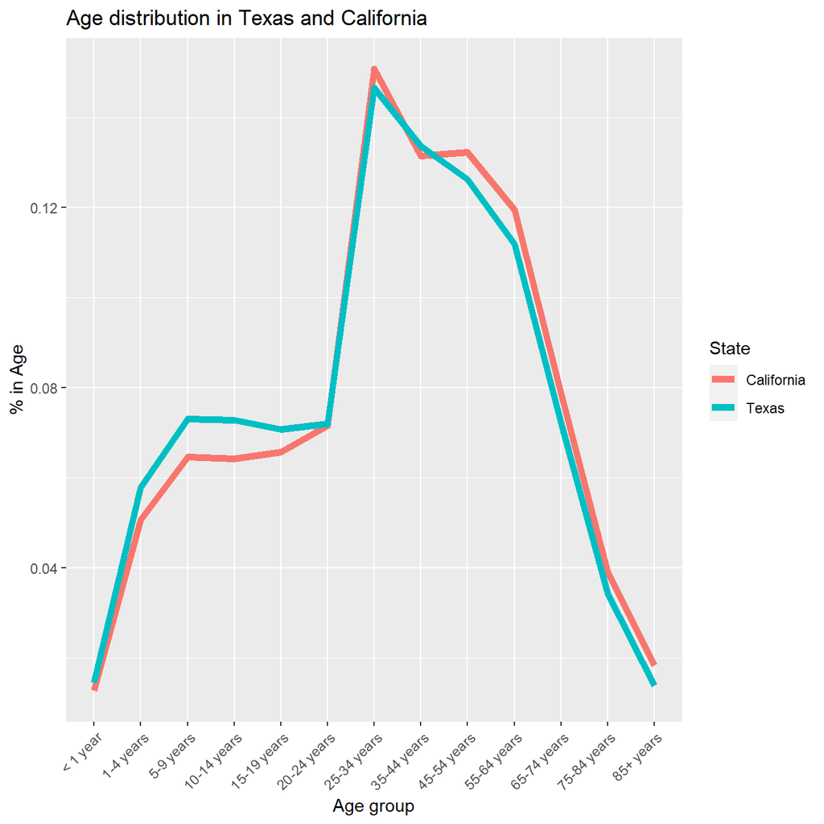

```r
txca%>%
  group_by(State)%>%
  summarise(p_pop = Population/sum(Population ))%>%
  ungroup()%>%
  mutate(age = forcats::fct_relevel(txca$Age_Group,"< 1 year",
                                    "1-4 years",
                                     "5-9 years",
                                    "10-14 years",
                                    "15-19 years",
                                    "20-24 years",
                                    "25-34 years",
                                    "35-44 years",
                                    "45-54 years",
                                    "55-64 years",
                                    "65-74 years",
                                    "75-84 years", "85+ years"
                                    ))%>%
  ggplot(aes(x = age, y = p_pop,group=State, color= State))+
  geom_line(lwd=2)+
  ylab("% in Age" )+
  xlab ("Age group")+
  ggtitle("Age distribution in Texas and California")+
  theme(axis.text.x = element_text(angle = 45, hjust = 1))
```

We see that the age distribution of Texas is slightly younger than California, also the large peak at 25-34 year age group is because the data adopt a 10 year age interval after age 25.

To do age standardization using the regression framework, we have to control for the differences in the age structure of the two populations (Texas and California) by regressing the mortality rate on the Age structure, the difference between the states after doing this is the difference in the age-standardized rate.

```r
txca<- txca%>%
  mutate(Age_Group = forcats::fct_relevel(txca$Age_Group,"< 1 year",
                                    "1-4 years",
                                     "5-9 years",
                                    "10-14 years",
                                    "15-19 years",
                                    "20-24 years",
                                    "25-34 years",
                                    "35-44 years",
                                    "45-54 years",
                                    "55-64 years",
                                    "65-74 years",
                                    "75-84 years", "85+ years"
                                    ))

glmb_s <- glm(cbind(Deaths, Population-Deaths) ~ factor(Age_Group)+State,
              data=txca,
              family=binomial)

glmb_s%>%
  tbl_regression(exp = TRUE)
```

| **Characteristic** | **OR**<sup>1</sup> | **95% CI**<sup>1</sup> | **p-value** |
| --- | --- | --- | --- |
| factor(Age_Group) |  |  |  |
| < 1 year | — | — |  |
| 1-4 years | 0.05 | 0.04, 0.05 | <0.001 |
| 5-9 years | 0.02 | 0.02, 0.03 | <0.001 |
| 10-14 years | 0.03 | 0.02, 0.03 | <0.001 |
| 15-19 years | 0.09 | 0.09, 0.10 | <0.001 |
| 20-24 years | 0.17 | 0.16, 0.18 | <0.001 |
| 25-34 years | 0.20 | 0.19, 0.21 | <0.001 |
| 35-44 years | 0.31 | 0.30, 0.32 | <0.001 |
| 45-54 years | 0.72 | 0.70, 0.75 | <0.001 |
| 55-64 years | 1.70 | 1.65, 1.75 | <0.001 |
| 65-74 years | 3.48 | 3.38, 3.59 | <0.001 |
| 75-84 years | 9.07 | 8.80, 9.35 | <0.001 |
| 85+ years | 30.4 | 29.5, 31.3 | <0.001 |
| State |  |  |  |
| California | — | — |  |
| Texas | 1.20 | 1.19, 1.21 | <0.001 |

<sup>*1*</sup> OR = Odds Ratio, CI = Confidence Interval

Which shows that Texas has a standardized mortality rate 20 percent higher than California.

## Poisson distribution

Another distribution commonly used in the analysis of place-based data is the Poisson distribution. The Poisson is applicable to outcomes that are positive integers, and is commonly used in epidemiology as a model of relative risk of a disease or mortality. The Poisson has a single parameter, the mean, $\lambda$, and it is really the average count for the outcome ($y$). We have several ways of modeling a count outcome with the Poisson

- *Pure count model* If each area or place has the same total area, risk set, or population size, then we can model the mean as-is. This would lead to a model that looks like:

$$log(\lambda)= \beta_0 + \beta_1 x_1$$

When we see the $\beta_1$ parameter in this model in computer output, it is on the log-scale, since that is the scale of the outcome for the Poisson model. In order to interpret the $\beta_1$, we have to *exponentiate* it. When we do this, the parameter is interpreted as the *percentage change in the mean of the outcome*, for a 1 unit change in $x_1$. For instance if we estimate a model and see in the output that $\beta_1 = \text{.025}$, then $\exp(\beta_1) = \text{exp}(\text{.025}) = \text{1.025}$, or for a 1 unit increase in $x_1$, the mean of $y$ increases by 1.025. So if the mean of $y$ is 10, when $x_1$ = 0, then the mean is $10*(1.025*1)$ or $10.25$ when $x_1$ = 1. This application of the Poisson is rare in demographic research because places rarely have either equal populations or areas, so the *Rate Model* or the *Relative Risk Model* are much more commonly used.

- *Rate model* The second type of modeling strategy used in the Poisson model is for a rate of occurrence. This model includes an *offset term* in the model to incorporate unequal population sizes, this is the most common way the data are analyzed in demographic research. This offset term can be thought of as the denominator for the rate, and we can show how it is included in the model.

If $n$ is the population size for each place, then, we want to do a regression on the rate of occurrence of our outcome. The rate is typically expressed as a proportion, or probability $rate = \frac{y}{n}$, as seen in the Binomial distribution earlier:

$$log(y/n)= \beta_0 + \beta_1 x_1 \\
log(y) - log(n)= \beta_0 + \beta_1 x_1\\
log(y)= \beta_0 + \beta_1 x_1 + log(n)$$

Similar to the example from before, when interpreting the effect of $\beta_1$ in this model, we also have to exponentiate it. In this case, the interpretation would not be related to the overall count, but to the rate of occurrence. So, if as before, the $\beta_1 = \text{.025}$, then $\exp(\beta_1) = \text{exp}(\text{.025}) = \text{1.025}$, or for a 1 unit increase in $x_1$, the *rate* of occurrence of $y$ increases by a factor of 1.025.

This model includes the natural log of the population size in the `offset()` function on the right side of the model formula. R will not estimate a regression coefficient for this term, and as in the equation above, the term just represents a scale factor for the outcome.

**Note on offsets** It is important to ensure that all of the populations in a particular analysis have non-zero counts, because if the model sees $log(0)$ in data, it will generate an error, because this is not a number.

```r
log(0)
```

```
## [1] -Inf
```

The Poisson model with a population offset is specified as:

```r
glmp_s <- glm(Deaths ~ offset(log(Population)) + factor(Age_Group) + State,
              data=txca,
              family=poisson)

glmp_s%>%
  tbl_regression(exp = TRUE)
```

| **Characteristic** | **IRR**<sup>1</sup> | **95% CI**<sup>1</sup> | **p-value** |
| --- | --- | --- | --- |
| factor(Age_Group) |  |  |  |
| < 1 year | — | — |  |
| 1-4 years | 0.05 | 0.04, 0.05 | <0.001 |
| 5-9 years | 0.02 | 0.02, 0.03 | <0.001 |
| 10-14 years | 0.03 | 0.03, 0.03 | <0.001 |
| 15-19 years | 0.10 | 0.09, 0.10 | <0.001 |
| 20-24 years | 0.17 | 0.16, 0.18 | <0.001 |
| 25-34 years | 0.20 | 0.19, 0.21 | <0.001 |
| 35-44 years | 0.31 | 0.30, 0.32 | <0.001 |
| 45-54 years | 0.72 | 0.70, 0.75 | <0.001 |
| 55-64 years | 1.69 | 1.64, 1.74 | <0.001 |
| 65-74 years | 3.44 | 3.33, 3.54 | <0.001 |
| 75-84 years | 8.73 | 8.47, 9.00 | <0.001 |
| 85+ years | 26.6 | 25.8, 27.4 | <0.001 |
| State |  |  |  |
| California | — | — |  |
| Texas | 1.19 | 1.18, 1.19 | <0.001 |

<sup>*1*</sup> IRR = Incidence Rate Ratio, CI = Confidence Interval

This result is very close to that from the Binomial model, where we see after age standardization, Texas has a 19 percent higher mortality rate overall than California.

## Relative risk analysis

The third type of model for the Poisson distribution focuses on the idea of the relative risk of an event, and uses the *Standardized risk ratio* as its currency.

- The *Standardized risk ratio* incorporates differential exposure due to population size as an *expected count* of the outcome in the offset term, and are typically seen in epidemiological studies. The expected count $E$, incorporates the different population sizes of each area by estimating the number of events that **should occur**, if the area followed a given rate of occurrence. The expected count is calculated by multiplying the average rate of occurrence, $r$, by the population size, $n$: $E_i = r * n_i$, where $r = \frac{\sum y_i}{\sum n_i}$, is the overall rate in the population. This method is commonly referred to as *internal standardization* because we are using the data at hand to estimate the overall rate of occurrence, versus using a rate from some other published source.

The model for the mean of the outcome would look like this:

$$log(y)= \beta_0 + \beta_1 x_1 + log(E)$$
.

And is specified very similarly to the rate model above. First, I show how to calculate the expected number of deaths in the data. A naive method of calculating the expected counts is to use the crude death rate as $r$, or we can use an age-specific death rate.

```r
#crude death rate
txca$E<- txca$Population*(sum(txca$Deaths/sum(txca$Population)))
```

In this calculation, the `Population` variable is multiplied by $r$, which is the sum of all deaths, divided by all populations.

The age-specific expected count is a little more involved. We first have to sum all deaths and populations by age, then calculate the age specific rate, then join this back to the original data based on the `Age_Group` variable. Is this the only way to do this, no, but it works in this example. Alternatively, we could get another age schedule of mortality rates and merge it to these data and standardize our data to that mortality schedule.

```r
#Age specific death rate
txca2<- txca%>%
  group_by(Age_Group)%>%
  summarise(ndeaths = sum(Deaths), npop=sum(Population))%>%
  mutate(r_age = ndeaths/npop)%>%
  ungroup()%>%
  left_join(., txca, by = "Age_Group")%>%
  arrange(State, Age_Group)%>%
  mutate(E_age = Population * r_age)

txca2%>%
  select(State, Age_Group, Deaths, Population, E, E_age)%>%
  gt()
```

| State | Age_Group | Deaths | Population | E | E_age |
| --- | --- | --- | --- | --- | --- |
| California | < 1 year | 2057 | 498832 | 3375.789 | 2395.1055 |
| California | 1-4 years | 397 | 1988540 | 13457.219 | 458.2383 |
| California | 5-9 years | 253 | 2539626 | 17186.631 | 293.4640 |
| California | 10-14 years | 277 | 2522475 | 17070.564 | 330.3049 |
| California | 15-19 years | 1076 | 2579986 | 17459.763 | 1176.4386 |
| California | 20-24 years | 2090 | 2812191 | 19031.184 | 2287.7627 |
| California | 25-34 years | 5201 | 5917785 | 40047.939 | 5682.6280 |
| California | 35-44 years | 7032 | 5159932 | 34919.255 | 7736.8039 |
| California | 45-54 years | 16370 | 5195297 | 35158.583 | 17888.9759 |
| California | 55-64 years | 34176 | 4688718 | 31730.368 | 37750.7084 |
| California | 65-74 years | 45834 | 3089002 | 20904.471 | 50503.1685 |
| California | 75-84 years | 59121 | 1535300 | 10389.969 | 63613.0044 |
| California | 85+ years | 88331 | 722333 | 4888.307 | 90772.2323 |
| Texas | < 1 year | 2287 | 405899 | 2746.875 | 1948.8945 |
| Texas | 1-4 years | 433 | 1613272 | 10917.635 | 371.7617 |
| Texas | 5-9 years | 276 | 2038319 | 13794.093 | 235.5360 |
| Texas | 10-14 years | 319 | 2029062 | 13731.447 | 265.6951 |
| Texas | 15-19 years | 999 | 1970588 | 13335.731 | 898.5614 |
| Texas | 20-24 years | 1829 | 2005169 | 13569.754 | 1631.2373 |
| Texas | 25-34 years | 4405 | 4085728 | 27649.701 | 3923.3720 |
| Texas | 35-44 years | 6292 | 3726287 | 25217.225 | 5587.1961 |
| Texas | 45-54 years | 13636 | 3519013 | 23814.522 | 12117.0241 |
| Texas | 55-64 years | 28663 | 3116019 | 21087.305 | 25088.2916 |
| Texas | 65-74 years | 37506 | 2008449 | 13591.951 | 32836.8315 |
| Texas | 75-84 years | 44144 | 957001 | 6476.396 | 39651.9956 |
| Texas | 85+ years | 51173 | 387790 | 2624.325 | 48731.7677 |

In this table, you can see the age-specific expected counts of deaths are much more in line with the age-specific mortality rate, and the numbers of expected deaths are much more similar to the observed pattern of deaths, when compared to the expected counts derived from the crude death rate.

```r
glmp_E <- glm(Deaths ~ offset(log(E)) + factor(Age_Group)+State,
              data=txca2,
              family=poisson)

glmp_Eage <- glm(Deaths ~ offset(log(E_age)) + factor(Age_Group)+State,
              data=txca2,
              family=poisson)

m1 <- glmp_E%>%
  tbl_regression(exp = T)
m2 <- glmp_Eage%>%
  tbl_regression(exp = T)

m_all <- tbl_merge(list(m1, m2))

m_all
```

| **Characteristic** | **Table 1** **IRR**<sup>1</sup> | **Table 1** **95% CI**<sup>1</sup> | **Table 1** **p-value** | **Table 2** **IRR**<sup>1</sup> | **Table 2** **95% CI**<sup>1</sup> | **Table 2** **p-value** |
| --- | --- | --- | --- | --- | --- | --- |
| factor(Age_Group) |  |  |  |  |  |  |
| < 1 year | — | — |  | — | — |  |
| 1-4 years | 0.05 | 0.04, 0.05 | <0.001 | 1.00 | 0.93, 1.08 | >0.9 |
| 5-9 years | 0.02 | 0.02, 0.03 | <0.001 | 1.00 | 0.91, 1.09 | >0.9 |
| 10-14 years | 0.03 | 0.03, 0.03 | <0.001 | 1.00 | 0.92, 1.09 | >0.9 |
| 15-19 years | 0.10 | 0.09, 0.10 | <0.001 | 1.00 | 0.95, 1.06 | >0.9 |
| 20-24 years | 0.17 | 0.16, 0.18 | <0.001 | 1.01 | 0.96, 1.05 | 0.8 |
| 25-34 years | 0.20 | 0.19, 0.21 | <0.001 | 1.01 | 0.97, 1.04 | 0.7 |
| 35-44 years | 0.31 | 0.30, 0.32 | <0.001 | 1.01 | 0.97, 1.04 | 0.8 |
| 45-54 years | 0.72 | 0.70, 0.75 | <0.001 | 1.01 | 0.98, 1.04 | 0.6 |
| 55-64 years | 1.69 | 1.64, 1.74 | <0.001 | 1.01 | 0.98, 1.04 | 0.6 |
| 65-74 years | 3.44 | 3.33, 3.54 | <0.001 | 1.01 | 0.98, 1.04 | 0.5 |
| 75-84 years | 8.73 | 8.47, 9.00 | <0.001 | 1.01 | 0.98, 1.04 | 0.5 |
| 85+ years | 26.6 | 25.8, 27.4 | <0.001 | 1.02 | 0.99, 1.05 | 0.3 |
| State |  |  |  |  |  |  |
| California | — | — |  | — | — |  |
| Texas | 1.19 | 1.18, 1.19 | <0.001 | 1.19 | 1.18, 1.19 | <0.001 |

<sup>*1*</sup> IRR = Incidence Rate Ratio, CI = Confidence Interval

This result is identical in terms of the difference between states, as the rate model above, and the results are invariant to the choice of the standard used, although when the age-specific expected count is used, the overall mortality pattern becomes insignificant in the model. This is an example of, despite different denominator/offset terms, we can achieve the same comparison from either the rate model or the model for relative risks.

## Overdispersion

When using the Poisson GLM, you often run into *overdispersion*. What’s overdispersion you might ask? For the Poisson distribution, the mean and the variance are functions of one another (variance = mean for Poisson). So when you have more variability than you expect in your data, you have overdispersion. This basically says that your data do not fit your model, and is a problem because overdispersion leads to standard errors for our model parameters that are too small typically. But, we can fit other models that do not make such assumptions, or allow there to be more variability.

#### Checking for overdispersion

An easy check on this is to compare the residual deviance to the residual degrees of freedom. They ratio should be 1 if the model fits the data.

```r
scale<-sqrt(glmp_E$deviance/glmp_E$df.residual)
scale
```

[output not shown]

Here, we see for the Poisson model, the scale factor is over 6, which shows evidence of overdispersion in the data. The residual deviance can also be used as a goodness of fit test for the model, because the deviance has been shown to be distributed as a $\chi^2$ distribution, with degrees of freedom equal to the residual d.f. (n-p):

```r
1-pchisq(glmp_E$deviance,
         df = glmp_E$df.residual)
```

[output not shown]

So, this p value is 0, which means the model does not fit the data. If the goodness of fit test had a p-value over 5 percent, we could conclude that the model in fact did fit the data.

## Modeling Overdispersion via a Quasi distribution

For the Poisson and the Binomial, we can fit a “quasi” distribution that adds an extra parameter to allow the mean-variance relationship to not be constant. For Poisson we get:

$Var(Y) = \lambda * \phi$, instead of $Var(Y) = \lambda$

This accessory parameter $\phi$ allows us to include a rough proxy for a dispersion parameter for the distribution. Naturally this is fixed at 1 for the normal Poisson model, and estimated in the quasi models, we can look to see if is much bigger than 1. If overdispersion is present and not accounted for you could identify a relationship as being significant when it is not!

```r
glmqp <- glm(Deaths ~ offset(log(E)) + factor(Age_Group)+State,
              data=txca,
              family=quasipoisson)

glmqp%>%
  tbl_regression(exp = TRUE)
```

| **Characteristic** | **IRR**<sup>1</sup> | **95% CI**<sup>1</sup> | **p-value** |
| --- | --- | --- | --- |
| factor(Age_Group) |  |  |  |
| < 1 year | — | — |  |
| 1-4 years | 0.05 | 0.03, 0.07 | <0.001 |
| 5-9 years | 0.02 | 0.01, 0.04 | <0.001 |
| 10-14 years | 0.03 | 0.02, 0.05 | <0.001 |
| 15-19 years | 0.10 | 0.07, 0.13 | <0.001 |
| 20-24 years | 0.17 | 0.13, 0.22 | <0.001 |
| 25-34 years | 0.20 | 0.16, 0.25 | <0.001 |
| 35-44 years | 0.31 | 0.25, 0.39 | <0.001 |
| 45-54 years | 0.72 | 0.59, 0.89 | 0.008 |
| 55-64 years | 1.69 | 1.40, 2.06 | <0.001 |
| 65-74 years | 3.44 | 2.85, 4.19 | <0.001 |
| 75-84 years | 8.73 | 7.25, 10.6 | <0.001 |
| 85+ years | 26.6 | 22.1, 32.4 | <0.001 |
| State |  |  |  |
| California | — | — |  |
| Texas | 1.19 | 1.14, 1.23 | <0.001 |

<sup>*1*</sup> IRR = Incidence Rate Ratio, CI = Confidence Interval

While the overall pattern and substantive interpretation of the regular Poisson and the quasiPoisson models are identical, the standard errors of the parameters are not. We can see this by forming their ratios. The standard errors of the model parameters can be extracted from the `summary()$coefficients` of a model, specifically the second column of this table.

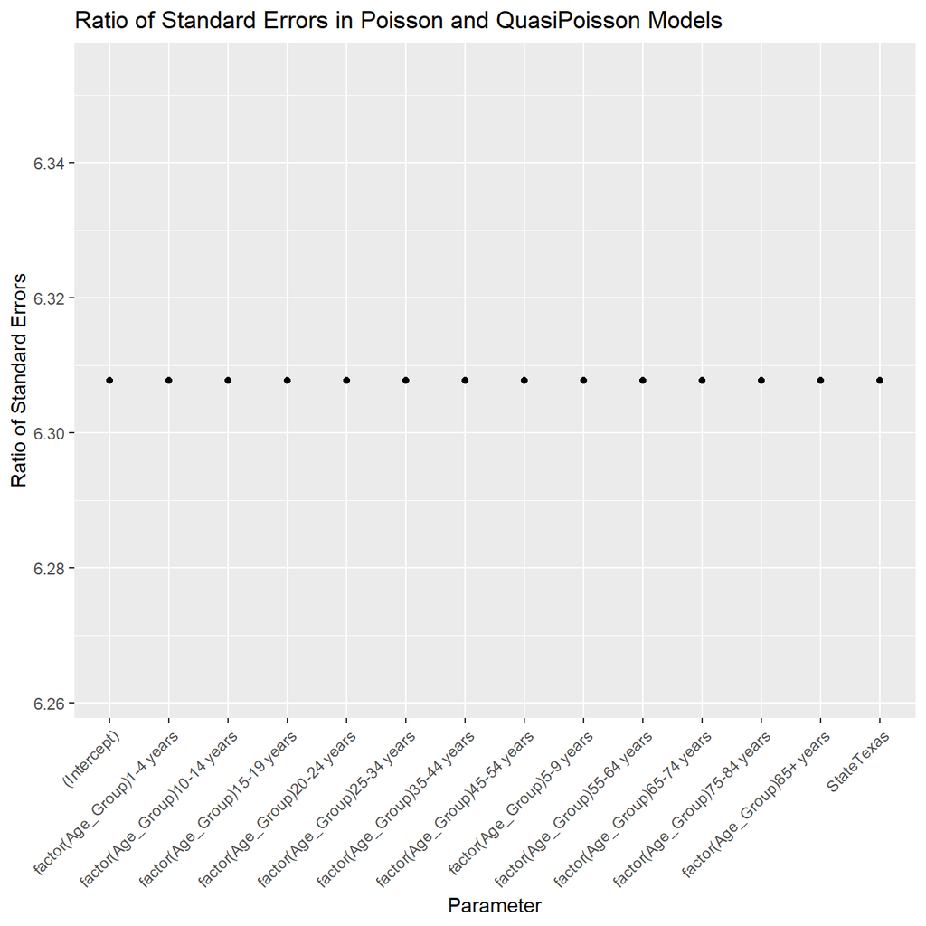

```r
sum1<- summary(glmp_E)$coef[, 2]
sum2<- summary(glmqp)$coef[, 2]

data.frame(Poisson = sum1,
           QPoisson= sum2,
           coef = names(coef(glmp_E)))%>%
  ggplot(aes(y = QPoisson/Poisson, x= coef))+
  geom_point()+
  ylab("Ratio of Standard Errors" )+
  xlab ("Parameter")+
  ggtitle("Ratio of Standard Errors in Poisson and QuasiPoisson Models")+
  theme(axis.text.x = element_text(angle = 45, hjust = 1))
```

This **highly meaningful** plot shows the ratio of all the standard errors is the same and is equal to the square root of the quasiPoisson dispersion parameter $\phi$, which can be seen in `summary(glmqp)$dispersion`, in this case it is 6.3079315, which is extremely close to the `scale` we calculated earlier. The quasiPoisson model has a disadvantage however, in that, per the `?glm` documentation, is fit via quasi-likelihood methods and as such cannot be compared using AIC to other models.

### Modeling dispersion properly

The `dispmod` package implements the method of Breslow (1984) which adds an extra parameter to account for the overdispersion in the Poisson, and is fit via regular maximum likelihood, so it is comparable to other models. Effectively, this takes either a model fit via `glm()` with either a Binomial or Poisson family, and performs a re-weighted estimate of the model parameters.

```r
library(dispmod)

glmp_d <- glm.poisson.disp(glmp_E,
                           verbose = F)

glmp_d%>%
  tbl_regression(exp = T)
```

| **Characteristic** | **IRR**<sup>1</sup> | **95% CI**<sup>1</sup> | **p-value** |
| --- | --- | --- | --- |
| factor(Age_Group) |  |  |  |
| < 1 year | — | — |  |
| 1-4 years | 0.05 | 0.04, 0.05 | <0.001 |
| 5-9 years | 0.02 | 0.02, 0.03 | <0.001 |
| 10-14 years | 0.03 | 0.02, 0.03 | <0.001 |
| 15-19 years | 0.10 | 0.09, 0.10 | <0.001 |
| 20-24 years | 0.17 | 0.16, 0.19 | <0.001 |
| 25-34 years | 0.20 | 0.18, 0.22 | <0.001 |
| 35-44 years | 0.31 | 0.29, 0.34 | <0.001 |
| 45-54 years | 0.72 | 0.66, 0.79 | <0.001 |
| 55-64 years | 1.70 | 1.56, 1.85 | <0.001 |
| 65-74 years | 3.45 | 3.16, 3.76 | <0.001 |
| 75-84 years | 8.73 | 8.01, 9.52 | <0.001 |
| 85+ years | 26.4 | 24.2, 28.8 | <0.001 |
| State |  |  |  |
| California | — | — |  |
| Texas | 1.24 | 1.20, 1.29 | <0.001 |

<sup>*1*</sup> IRR = Incidence Rate Ratio, CI = Confidence Interval

In this example the difference between California and Texas is now larger at a 24% higher mortality rate in Texas. How does this model compare to the regular Poisson model?

```r
AIC(glmp_E, glmp_d)
```

|  | df | AIC |
| --- | --- | --- |
| glmp_E | 14 | 773.7668 |
| glmp_d | 14 | 90.3267 |

The dispersed model shows a much lower AIC suggesting that the dispersion accounted for in the the Breslow model is likely important. We can see how the dispersed Poisson model’s standard errors compare to those of the regular Poisson using the same plot we saw earlier:

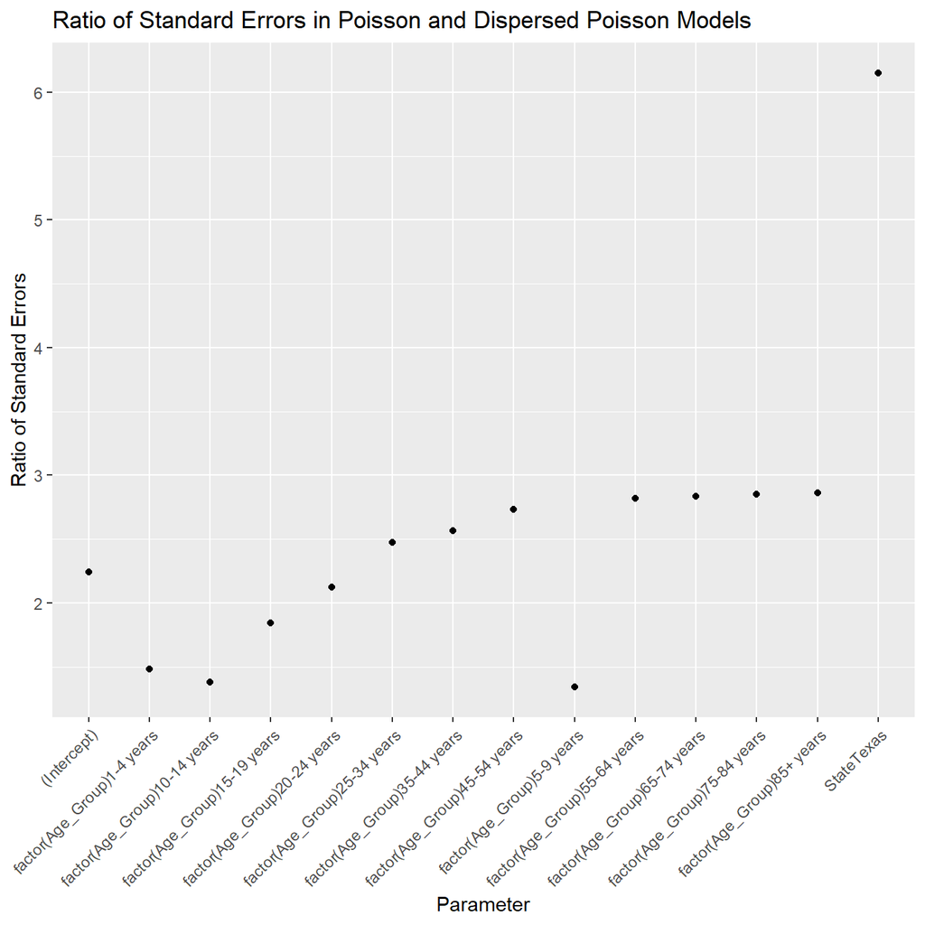

In this case, the standard errors are not just a monotone transformation of the Poisson model errors, they each have their own scaling, which shows the dispersed Poisson model is doing something different compared to the quasiPoisson model by not using a single scaling factor for all the standard errors.

## Other count models

The Poisson and Binomial models are probably the most commonly used models for rates and proportions, but other models exist that offer more flexibility. Specifically the Beta distribution and the Negative Binomial distribution.

### Beta distribution model

The Beta distribution is a commonly used model for the prior distribution for the mean of the Binomial, as it has values between 0 and 1, but it is not used as often as an outcome distribution. It is indeed quite flexible as an outcome distribution for proportions because of its range of support, but also because it has an additional dispersion parameter, unlike the Binomial, so the pitfalls of overdispersion often present in the Binomial can be avoided. The `betareg` package (Grün, Kosmidis, and Zeileis 2012) implements the Beta regression model. The distribution has density:

$$f(y:p,q) = \frac{\Gamma(p +
q)}{\Gamma(p)\Gamma(q)}x^{p - 1}(1 - x)^{q - 1}$$
Where $\Gamma$ is the Gamma function. The distribution, as parameterized in `betareg` has mean and variance:

$$\mu = p/(p+q) \\
Var = \mu (1-\mu)/ (1+\phi)$$

Where $phi$ is a precision parameter. The model is linked to the linear predictor using one of the same link functions as the Binomial model: Logit, Probit or Complementary Log-Log.

$$g(\mu_i) = X'\beta = \eta_i$$
The Logit link is parameterized as:

$$logit(g(\mu)) = log(\mu / (1-\mu))$$
As described in their article on the `betareg` package (Cribari-Neto and Zeileis 2010), the model can also include a separate model for dispersion, so you can model the variance in the data as well as the mean.

The `betareg::betareg()` function implements model, and here is an application of the model to the low birth weight data used earlier:

```r
library(betareg)
glm_beta<-betareg(I(lbrate1618/1000) ~  fampov14 + rucc + hpsa16,
                  data=ahrf_m)

summary(glm_beta)
```

```
##
## Call:
## betareg(formula = I(lbrate1618/1000) ~ fampov14 + rucc + hpsa16, data = ahrf_m)
##
## Standardized weighted residuals 2:
##     Min      1Q  Median      3Q     Max
## -7.0393 -0.6234 -0.0110  0.6338  3.7500
##
## Coefficients (mean model with logit link):
##                                 Estimate Std. Error  z value Pr(>|z|)
## (Intercept)                   -2.6387868  0.0150612 -175.204  < 2e-16 ***
## fampov14                       0.0252868  0.0007936   31.862  < 2e-16 ***
## rucc02                        -0.0188140  0.0150716   -1.248 0.211917
## rucc03                        -0.0400036  0.0157581   -2.539 0.011129 *
## rucc04                        -0.0798596  0.0177856   -4.490 7.12e-06 ***
## rucc05                        -0.0734111  0.0242750   -3.024 0.002493 **
## rucc06                        -0.0494087  0.0142816   -3.460 0.000541 ***
## rucc07                        -0.0498176  0.0159746   -3.119 0.001817 **
## rucc08                         0.0038585  0.0252486    0.153 0.878541
## rucc09                        -0.0636793  0.0274465   -2.320 0.020334 *
## hpsa16partial county shortage -0.0019801  0.0128139   -0.155 0.877196
## hpsa16whole county shortage    0.0278359  0.0156183    1.782 0.074706 .
##
## Phi coefficients (precision model with identity link):
##       Estimate Std. Error z value Pr(>|z|)
## (phi)  304.733      8.948   34.06   <2e-16 ***
## ---
## Signif. codes:  0 '***' 0.001 '**' 0.01 '*' 0.05 '.' 0.1 ' ' 1
##
## Type of estimator: ML (maximum likelihood)
## Log-likelihood:  6347 on 13 Df
## Pseudo R-squared: 0.355
## Number of iterations: 23 (BFGS) + 2 (Fisher scoring)
```

And the model with a separate model for the dispersion can be estimated by including a second formula separated by a `|` as:

```r
library(betareg)
glm_beta_o<-betareg(I(lbrate1618/1000) ~  fampov14 + rucc + hpsa16 | scale(popn),
                  data=ahrf_m)

summary(glm_beta_o)
```

```
##
## Call:
## betareg(formula = I(lbrate1618/1000) ~ fampov14 + rucc + hpsa16 | scale(popn),
##     data = ahrf_m)
##
## Standardized weighted residuals 2:
##     Min      1Q  Median      3Q     Max
## -6.9251 -0.6169 -0.0023  0.6500  3.7111
##
## Coefficients (mean model with logit link):
##                                 Estimate Std. Error  z value Pr(>|z|)
## (Intercept)                   -2.6421609  0.0149203 -177.085  < 2e-16 ***
## fampov14                       0.0251141  0.0007938   31.639  < 2e-16 ***
## rucc02                        -0.0124912  0.0146382   -0.853  0.39348
## rucc03                        -0.0327516  0.0154238   -2.123  0.03372 *
## rucc04                        -0.0721414  0.0175194   -4.118 3.83e-05 ***
## rucc05                        -0.0655256  0.0241470   -2.714  0.00666 **
## rucc06                        -0.0415704  0.0139537   -2.979  0.00289 **
## rucc07                        -0.0417441  0.0156940   -2.660  0.00782 **
## rucc08                         0.0118585  0.0252317    0.470  0.63837
## rucc09                        -0.0550535  0.0274518   -2.005  0.04491 *
## hpsa16partial county shortage -0.0048007  0.0127864   -0.375  0.70733
## hpsa16whole county shortage    0.0270952  0.0156837    1.728  0.08406 .
##
## Phi coefficients (precision model with log link):
##             Estimate Std. Error z value Pr(>|z|)
## (Intercept)  5.72714    0.02936 195.063  < 2e-16 ***
## scale(popn)  0.08419    0.02929   2.874  0.00405 **
## ---
## Signif. codes:  0 '***' 0.001 '**' 0.01 '*' 0.05 '.' 0.1 ' ' 1
##
## Type of estimator: ML (maximum likelihood)
## Log-likelihood:  6355 on 14 Df
## Pseudo R-squared: 0.3548
## Number of iterations: 21 (BFGS) + 1 (Fisher scoring)
```

The AIC can be used to determine if the dispersion model is preferred to the regular beta regression.

```r
AIC(glm_beta, glm_beta_o)
```

|  | df | AIC |
| --- | --- | --- |
| glm_beta | 13 | -12668.24 |
| glm_beta_o | 14 | -12682.02 |

In this case, the dispersion model is preferred since the AIC is 13.78 points lower for the dispersion model.

### Negative binomial model

When overdispersion is present, many researchers will automatically turn to the Negative Binomial as an alternative. The Negative Binomial sounds like it is some alternative to the Binomial distribution, but it is more like the Poisson. It effectively adds a second parameter to a model for integer counts. The model has been parameterized in several ways. The most common are the NB1 and NB2 models. The difference is how the model allows the variance to increase with the mean. The NB1 model allows for variance to increase linearly with the mean:

$$Y \sim NB (\lambda, \lambda+ \theta \lambda) \\
E(Y) = \lambda \\
\text{ } var(Y) = \lambda+\theta\lambda \\
\lambda = log(\eta) \\
\eta = \beta_0 + \beta_1 x_1+ log(n)$$
The NB2 model, which is the most commonly implemented in software, allows the variance to increase as a square with the mean.

$$Y \sim NB (\lambda, \lambda+ \theta \lambda^2) \\
E(Y) = \lambda \\
\text{ } var(Y) = \lambda+ \theta \lambda^2 \\
\lambda = log(\eta) \\
\eta = \beta_0 + \beta_1 x_1+ log(n)$$

```r
library(MASS)
glmnb<- glm.nb(Deaths ~ offset(log(Population)) + factor(Age_Group) +  State,
               data=txca)

glmnb%>%
  tbl_regression()
```

| **Characteristic** | **log(IRR)**<sup>1</sup> | **95% CI**<sup>1</sup> | **p-value** |
| --- | --- | --- | --- |
| factor(Age_Group) |  |  |  |
| < 1 year | — | — |  |
| 1-4 years | -3.0 | -3.1, -2.9 | <0.001 |
| 5-9 years | -3.7 | -3.8, -3.6 | <0.001 |
| 10-14 years | -3.6 | -3.7, -3.5 | <0.001 |
| 15-19 years | -2.4 | -2.4, -2.3 | <0.001 |
| 20-24 years | -1.8 | -1.8, -1.7 | <0.001 |
| 25-34 years | -1.6 | -1.7, -1.5 | <0.001 |
| 35-44 years | -1.2 | -1.2, -1.1 | <0.001 |
| 45-54 years | -0.32 | -0.38, -0.26 | <0.001 |
| 55-64 years | 0.53 | 0.47, 0.59 | <0.001 |
| 65-74 years | 1.2 | 1.2, 1.3 | <0.001 |
| 75-84 years | 2.2 | 2.1, 2.2 | <0.001 |
| 85+ years | 3.3 | 3.2, 3.3 | <0.001 |
| State |  |  |  |
| California | — | — |  |
| Texas | 0.21 | 0.18, 0.23 | <0.001 |

<sup>*1*</sup> IRR = Incidence Rate Ratio, CI = Confidence Interval

## References

Breslow, N. E. 1984. “Extra-Poisson Variation in Log-Linear Models.” *Applied Statistics* 33 (1): 38. https://doi.org/10.2307/2347661.

Bureau, US Census. 2019. “Worked Examples for Approximating Standard Errors Using American Community Survey Data.” https://www2.census.gov/programs-surveys/acs/tech_docs/accuracy/2018_ACS_Accuracy_Document_Worked_Examples.pdf.

Courtemanche, Charles, James Marton, Benjamin Ukert, Aaron Yelowitz, and Daniela Zapata. 2019. “Effects of the Affordable Care Act on Health Behaviors After 3 Years.” *Eastern Economic Journal* 45 (1): 7–33. https://doi.org/10.1057/s41302-018-0119-4.

Cribari-Neto, Francisco, and Achim Zeileis. 2010. “Beta Regression in *r*.” *Journal of Statistical Software* 34 (2). https://doi.org/10.18637/jss.v034.i02.

Division, United Nations Population. 1983. “Manual X: Indirect Techniques for Demographic Estimation.” New York, NY. https://www.un.org/en/development/desa/population/publications/manual/estimate/demographic-estimation.asp.

Grün, Bettina, Ioannis Kosmidis, and Achim Zeileis. 2012. “Extended Beta Regression in R: Shaken, Stirred, Mixed, and Partitioned.” *Journal of Statistical Software* 48 (11): 1–25. https://doi.org/10.18637/jss.v048.i11.

Keyfitz, Nathan. 1968. *Introduction to the Mathematics of Population*. Addison-Wesley Publishing Company.

Manson, Steven, Jonathan Schroeder, David Van Riper, Tracy Kugler, and Steven Ruggles. 2021. *IPUMS National Historical Geographic Information System: Version 16.0 [Dataset]*. https://doi.org/http://doi.org/10.18128/D050.V16.0.

McCullagh, P., and John A. Nelder. 1998. *Generalized Linear Models*. 2nd ed. Monographs on Statistics and Applied Probability 37. Boca Raton: Chapman & Hall/CRC.

Nelder, J. A., and R. W. M. Wedderburn. 1972. “Generalized Linear Models.” *Journal of the Royal Statistical Society: Series A (General)* 135 (3): 370–84. https://doi.org/10.2307/2344614.

Rigby, R. A., and D. M. Stasinopoulos. 2005. “Generalized Additive Models for Location, Scale and Shape,(with Discussion).” *Applied Statistics* 54.3: 507–54.

Soni, Aparna, Michael Hendryx, and Kosali Simon. 2017. “Medicaid Expansion Under the Affordable Care Act and Insurance Coverage in Rural and Urban Areas.” *The Journal of Rural Health* 33 (2): 217–26. https://doi.org/10.1111/jrh.12234.

Venables, W. N., and B. D. Ripley. 2002. *Modern Applied Statistics with s*. Fourth. New York: Springer. https://www.stats.ox.ac.uk/pub/MASS4/.

Voss, Paul R. 2007. “Demography as a Spatial Social Science.” *Population Research and Policy Review* 26 (5-6): 457–76. https://doi.org/10.1007/s11113-007-9047-4.

Walker, Kyle. 2021. *Tigris: Load Census TIGER/Line Shapefiles*. https://CRAN.R-project.org/package=tigris.

Walker, Kyle, and Matt Herman. 2021. *Tidycensus: Load US Census Boundary and Attribute Data as ’Tidyverse’ and ’Sf’-Ready Data Frames*. https://CRAN.R-project.org/package=tidycensus.

[^1]: $\bar{y}= \text{mean of y}$, $\bar{x}= \text{mean of x}$
[^2]: http://api.census.gov/data/key_signup.html
[^3]: Link to AHRF codebook - [“https://data.hrsa.gov/DataDownload/AHRF/AHRF_USER_TECH_2019-2020.zip”](https://data.hrsa.gov/DataDownload/AHRF/AHRF_USER_TECH_2019-2020.zip)
[^4]: More on this below
[^5]: Link to AHRF codebook - [“https://data.hrsa.gov/DataDownload/AHRF/AHRF_USER_TECH_2019-2020.zip”](https://data.hrsa.gov/DataDownload/AHRF/AHRF_USER_TECH_2019-2020.zip)